# Анализ данных транспортных маршрутов

**Цель** – проанализировать полученные данные.

**Задачи:**

- Предобработка данных
- Обзор и данных
- Визуализация и исследовательский анализ данных
- Выделение рейсов
- Поиск возможных ошибок в данных

**Данные**

- average_speed - Мгновенная скорость транспортного средства, полученная от приемника GPS, км/ч
- clid - Идентификатор участника программы
- direction - Направление движения в градусах (направление на север - 0 градусов). Диапазон значений 0-360
- lat - Широта точки в градусах.
- lon - Долгота точки в градусах.
- receive_time -
- route - Идентификатор маршрута.
- time - Дата и время получения координат точки от GPS-приемника (по Гринвичу).
- uuid - Уникальный идентификатор движущегося объекта (транспортного средства). Одинаковые uuid для разных типов транспорта (vehicle_type) недопустимы.
- vehicle_type - Тип общественного транспортного средства.

## Предобработка данных

```python
# Импорт библиотек
import warnings
import pandas as pd
import matplotlib.pyplot as plt
import seaborn as sns
from datetime import datetime
from sklearn.model_selection import train_test_split
from sklearn.preprocessing import StandardScaler
from scipy.cluster.hierarchy import linkage, fcluster

pd.options.display.float_format = '{:.3f}'.format
warnings.filterwarnings('ignore')
```

```python
# импорт данных
df = pd.read_csv("test_task_log1.txt", sep="	")
```

```python
# Функция обзора данных
def first_look(df):
    print('----------Первые 5 строк----------')
    display(df.head())
    print('\n')
    print('----------Тип данных----------')
    display(df.info())
    print('\n')
    print('----------Пропуски в данных----------')
    df_isna = df.isna().sum()
    if df_isna.sum().sum() > 0:
        display(df_isna.loc[df_isna > 0])
    else: print('Пропусков нет')
    print('\n')
    print('----------Дубликаты----------')
    if df.duplicated().sum() > 0:
        print('Дубликатов:', df.duplicated().sum())
    else:
        print('Дубликатов нет')
    print('\n')
```

```python
first_look(df)
```

```
----------Первые 5 строк----------
```

|  | average_speed | clid | direction | lat | lon | receive_time | route | time | uuid | vehicle_type |
| --- | --- | --- | --- | --- | --- | --- | --- | --- | --- | --- |
| 0 | 4.444 | c8g87gcr3 | 182.000 | 55.148 | 60.152 | 1701392963 | 3 | 1701392958 | 1463169 | trolleybus |
| 1 | 0.000 | c8g87gcr3 | 0.000 | 55.135 | 60.149 | 1701393293 | 3 | 1701393286 | 1463169 | trolleybus |
| 2 | 4.722 | c8g87gcr3 | 228.000 | 55.134 | 60.148 | 1701393323 | 3 | 1701393314 | 1463169 | trolleybus |
| 3 | 6.111 | c8g87gcr3 | 229.000 | 55.134 | 60.148 | 1701393323 | 3 | 1701393318 | 1463169 | trolleybus |
| 4 | 8.333 | c8g87gcr3 | 203.000 | 55.092 | 60.126 | 1701394067 | 3 | 1701394041 | 1463169 | trolleybus |

```
----------Тип данных----------
<class 'pandas.core.frame.DataFrame'>
RangeIndex: 167305 entries, 0 to 167304
Data columns (total 10 columns):
 #   Column         Non-Null Count   Dtype
---  ------         --------------   -----
 0   average_speed  167305 non-null  float64
 1   clid           167305 non-null  object
 2   direction      167305 non-null  float64
 3   lat            167305 non-null  float64
 4   lon            167305 non-null  float64
 5   receive_time   167305 non-null  int64
 6   route          167305 non-null  object
 7   time           167305 non-null  int64
 8   uuid           167305 non-null  int64
 9   vehicle_type   167305 non-null  object
dtypes: float64(4), int64(3), object(3)
memory usage: 12.8+ MB
```

```
None
```

```
----------Пропуски в данных----------
Пропусков нет


----------Дубликаты----------
Дубликатов: 69
```

Найдено 69 дубликатов. Их следует удалить, т.к. они не будут нести дополнительную информацию. Дубликаты могли появиться вследствие передачи данных чаще, чем за одну секунду.

```python
df = df.drop_duplicates()
print("Количество дубликатов: ", df.duplicated().sum())
```

```
Количество дубликатов:  0
```

Также следует удалить те строки, в которых `time` и `uuid` совпадают. Проверим есть ли такие.

```python
df.duplicated(["time", "uuid"]).sum()
```

```
503
```

Их 503 штуки. Тоже удалим эти строки, т.к. вряд ли транспортное средство претерпело значительное изменение положения менее чем за секунду.

```python
df = df.drop_duplicates(["time", "uuid"])
print("Количество дубликатов: ", df.duplicated(["time", "uuid"]).sum())
```

```
Количество дубликатов:  0
```

Возможно достаточно много строк с нулевой скоростью транспорта, которые не помогут в решении стоящих перед нами задач. И их удалим тоже.

```python
df = df[df["average_speed"] != 0]
```

Других действий предобработки не требуется.

## Обзор данных

### Обзор float и int характеристик

```python
# Функция для построения гистограммы и диаграммы размаха
def hist_maker(column, bins):
    print(column.describe())
    plt.figure(figsize=(10,6))
    plt.hist(column, bins=bins, color='grey', edgecolor='grey', alpha=0.8)
    plt.axvline(column.describe()['mean'], color='r', linestyle='dashed', linewidth=3, label='Mean value: {:.2f}'.format(column.describe()['mean']))
    plt.axvline(column.describe()['50%'], color='b', linestyle='dotted', linewidth=3, label='Median value: {:.0f}'.format(column.describe()['50%']))
    plt.xlabel(column.name)
    plt.ylabel('count')
    plt.legend()
    plt.title('Histogramm {}'.format(column.name))
    plt.figure(figsize=(20,2))
    sns.boxplot(x=column)
    plt.title('Boxplot {}'.format(column.name))
```

#### Средняя скорость

```
count   135973.000
mean         5.921
std          3.436
min          0.278
25%          3.056
50%          5.556
75%          8.333
max         22.222
Name: average_speed, dtype: float64
```

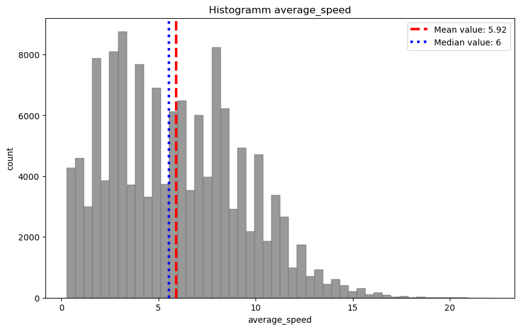

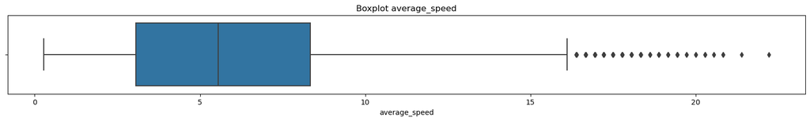

```python
hist_maker(df["average_speed"], 50)
```

Средняя скорость составила 5.92. Выдающиеся значения есть, но не будем с ними ничего делать, т.к. в дальнейшем анализе значения скорости не понадобятся.

#### Направление

```
count   135973.000
mean       139.761
std        113.251
min          0.000
25%         19.000
50%        179.000
75%        202.000
max        360.000
Name: direction, dtype: float64
```

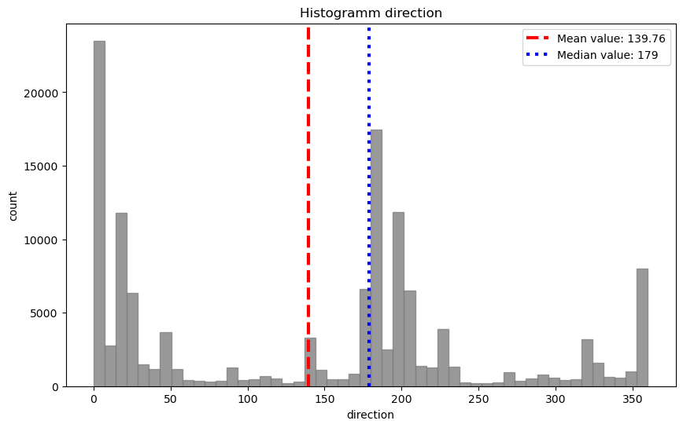

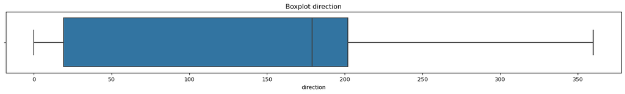

```python
hist_maker(df["direction"], 50)
```

Выделяются некоторые области направлений. Особенно много записей с околонулевыми значениями, что может быть связано с алгоритами расчёта расстояний. Вероятней эти сигналы были записаны, когда скорость движения транспорта была низкой. Однако график направления и связи не подтверждает эту гипотезу.

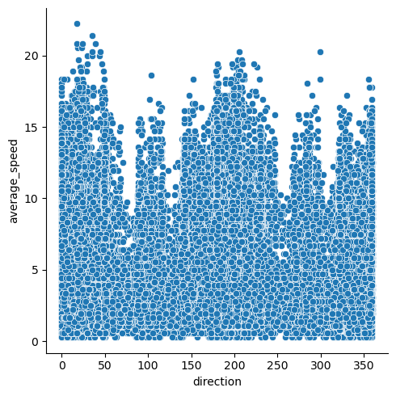

```python
sns.relplot(data=df, x="direction", y="average_speed");
```

#### Широта

```
count   135973.000
mean        55.093
std          0.044
min         54.977
25%         55.057
50%         55.088
75%         55.133
max         55.344
Name: lat, dtype: float64
```

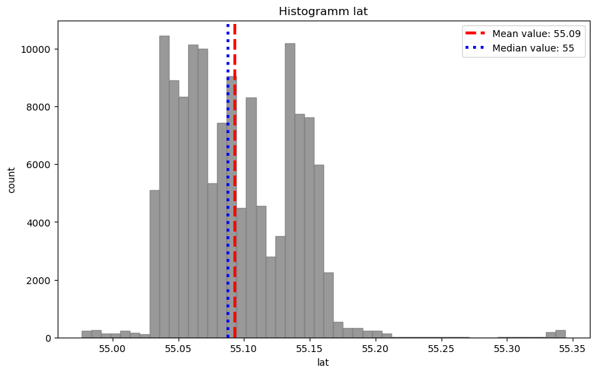

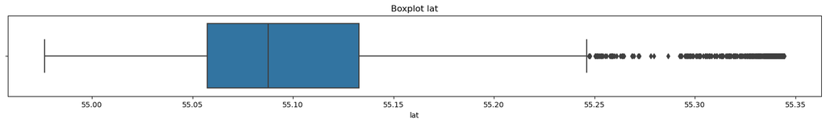

```python
hist_maker(df["lat"], 50)
```

Наблюдается выдающиеся значения. Они могут быть связаны как с отдельными маршрутами, так и с ошибками в данных.

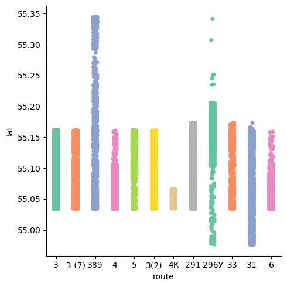

```python
sns.catplot(data=df, x="route", y="lat", palette="Set2");
```

#### Долгота

```
count   135973.000
mean        60.126
std          0.019
min         60.066
25%         60.110
50%         60.123
75%         60.142
max         60.230
Name: lon, dtype: float64
```

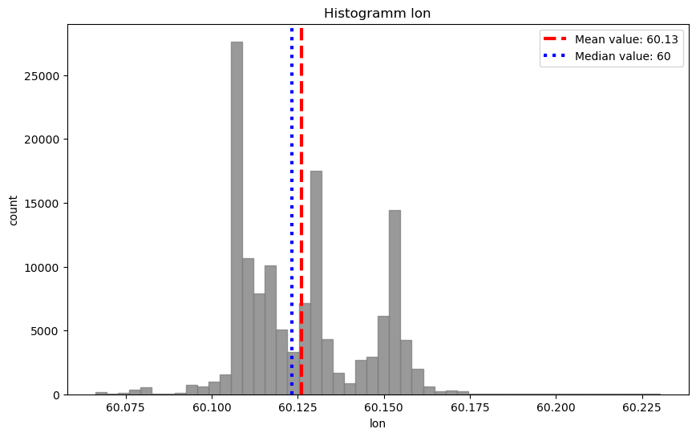

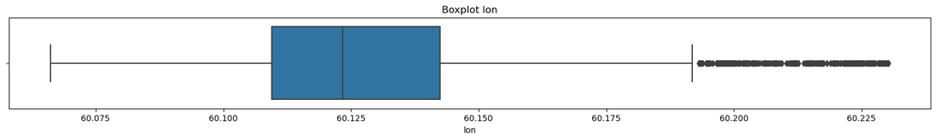

```python
hist_maker(df["lon"], 50)
```

По долготе выводы такиеже как и по широте. На гистограмме отмечаются участки с узкими диапазонами значений долготы. Это может указывать на меридианальность пространственного положения маршрутов транспорта. Т.е. маршруты скорее всего проходят по дорожной инфраструктре вытянутой с юга на север.

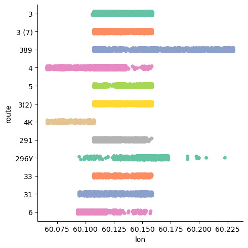

```python
sns.catplot(data=df, y="route", x="lon", palette="Set2");
```

#### Время

```
count       135973.000
mean    1701509631.484
std         170341.643
min     1701305555.000
25%     1701357631.000
50%     1701425584.000
75%     1701685070.000
max     1701809515.000
Name: time, dtype: float64
```

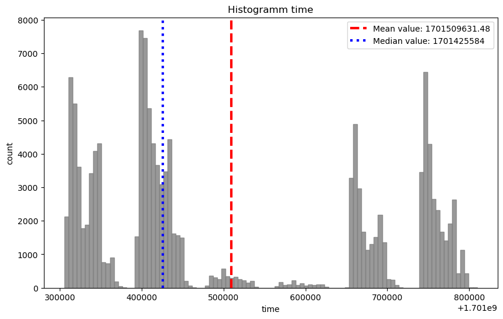

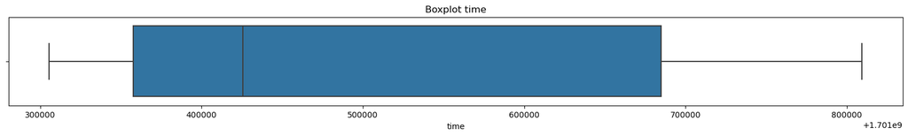

```python
hist_maker(df["time"], 100)
```

На гистограмме времени хорошо выделяется суточный ход записи. Увеличение количества строк соответствует дневному времени суток. Посмотрим за какое время были предоставлены данные.

```python
time_min = datetime.utcfromtimestamp(df["time"].min())
time_max = datetime.utcfromtimestamp(df["time"].max())

print("Период данных: ", time_min, " – ", time_max)
print("Номер дня недели: ", time_min.weekday(), " – ", time_max.weekday())
```

```
Период данных:  2023-11-30 00:52:35  –  2023-12-05 20:51:55
Номер дня недели:  3  –  1
```

Мы также посмотрели и на дни недели. Наименьшая активность характерна для выходных дней.

### Обзор object характеристик

#### Маршруты

Маршруты по которым передавались сигналы.

```python
print("Номера маршрутов: ", list(df["route"].unique()))
print("Количество маршрутов: ", len(df["route"].unique()))
```

```
Номера маршрутов:  ['3', '3 (7)', '389', '4', '5', '3(2)', '4К', '291', '296У', '33', '31', '6']
Количество маршрутов:  12
```

#### Транспортные средства

Сколько транспортных средств передавали данные по маршрутам?

```python
df.groupby(["route"])["uuid"].nunique().sort_values(ascending=False)
```

```
route
3        29
4        17
291       8
31        8
3 (7)     7
296У      6
3(2)      6
6         5
33        4
4К        4
5         4
389       1
Name: uuid, dtype: int64
```

Сложим эти транспортные средства.

```python
df.groupby(["route"])["uuid"].nunique().sum()
```

```
99
```

```python
print("Общее количество уникальных транспортных средств: ", df["uuid"].nunique())
```

```
Общее количество уникальных транспортных средств:  45
```

Можно сделать вывод о том, что одно и то же транспортное средство может ездить по разным маршрутам.

### Рейсы

Согласно Википедии рейс это путь транспортного средства (корабля, судна, автомобиля, летательного аппарата и так далее) по определённому маршруту.

Рейсы в данных не выделены явно, поэтому в рамках тестового задания необходимо разработать методологию выделния рейса по доступным данным с целью выполнения последующих задач.

Пожалуй для этой цели лучше всего подоходят данные о времени. На гистограмме ниже приведён пример для транспортного средства №1463178 маршрута №3. На нём достаточно хорошо выделяются периоды "активности".

```python
df[df["route"] == "3"]["uuid"].unique()
```

```
array([1463169, 1463178, 1463183, 1463538, 1504621, 1504623, 1504626,
       1504631, 1504827, 1504831, 1504833, 1504834, 1504839, 1504846,
       1504912, 1504916, 1504917, 9028617, 9058974, 1504624, 1504625,
       1504838, 1504848, 1480169, 1504830, 1504856, 1504841, 1504844,
       9058975], dtype=int64)
```

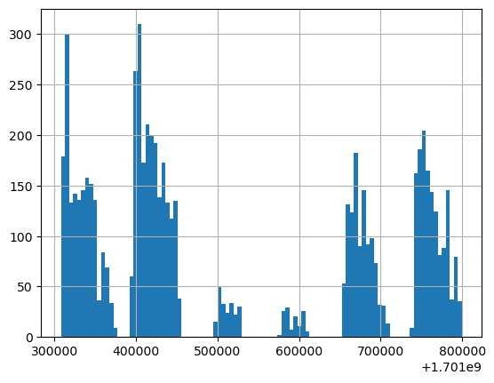

```python
df[(df["route"] == "3") & (df["uuid"] == 1463178)]["time"].hist(bins=100);
```

Подготовим функцию для выделения рейсов.

Описание работы функции:

- Сначала она создает пустой DataFrame df_concat_route, который будет содержать результаты кластеризации для всех маршрутов.
- Затем она итерируется по уникальным значениям маршрутов в столбце "route" переданного DataFrame df.
- Для каждого маршрута она создает новый пустой DataFrame df_concat_uuid, который будет содержать результаты кластеризации для всех уникальных uuid на данном маршруте.
- Затем она фильтрует исходные данные df, чтобы получить только записи, относящиеся к текущему маршруту, и извлекает уникальные значения uuid для этого маршрута.
- Далее она итерируется по уникальным uuid и для каждого из них фильтрует данные, чтобы получить только записи с этим uuid на текущем маршруте.
- Для каждого uuid она извлекает временной ряд X, стандартизирует его с использованием StandardScaler, затем выполняет кластеризацию с помощью метода linkage, используя критерий объединения 'ward'.
- Определяется пороговое значение расстояния (threshold), и кластерные метки вычисляются с помощью fcluster.
- К кластерным меткам добавляются метки, содержащие информацию о маршруте и uuid, и сохраняются в столбец clusters.
- Результаты кластеризации для данного uuid на текущем маршруте добавляются к df_concat_uuid.
- Наконец, результаты для всех uuid на текущем маршруте объединяются с результатами для других маршрутов в df_concat_route, и возвращается итоговый DataFrame

```python
def get_raise(df):
    df_concat_route = pd.DataFrame()
    route_list = df["route"].unique()
    for route in route_list:
        df_concat_uuid = pd.DataFrame()
        uuid_list = df[df["route"] == route]["uuid"].unique()
        df_route = df[df["route"]== route]

        for uuid in uuid_list:
            df_uuid = df_route[df_route["uuid"]==uuid]
            X = df_uuid['time'].reset_index()

            # стандартизируем данные
            scaler = StandardScaler()
            scaler.fit(X) # обучите scaler на обучающей выборке методом fit
            X_st = scaler.transform(X) # стандартизируем обучающую выборку методом transform scaler
            linked = linkage(X_st, method='ward')

            # определяем кластеры на основе порогового значения расстояния
            threshold = 15.0  # подобрам эмперическим путём
            cluster_labels = fcluster(linked, threshold, criterion='distance')

            cluster_labels_route = []

            for i in cluster_labels:
                name = str(route) + "_" + str(uuid) + "_" + str(i)
                cluster_labels_route.append(name)

            df_uuid['raises'] = cluster_labels_route

            df_concat_uuid = pd.concat([df_concat_uuid, df_uuid])

        df_concat_route = pd.concat([df_concat_route, df_concat_uuid])

    return df_concat_route
```

```python
df_raise = get_raise(df)
```

```python
df_raise.head()
```

|  | average_speed | clid | direction | lat | lon | receive_time | route | time | uuid | vehicle_type | raises |
| --- | --- | --- | --- | --- | --- | --- | --- | --- | --- | --- | --- |
| 0 | 4.444 | c8g87gcr3 | 182.000 | 55.148 | 60.152 | 1701392963 | 3 | 1701392958 | 1463169 | trolleybus | 3_1463169_1 |
| 2 | 4.722 | c8g87gcr3 | 228.000 | 55.134 | 60.148 | 1701393323 | 3 | 1701393314 | 1463169 | trolleybus | 3_1463169_1 |
| 3 | 6.111 | c8g87gcr3 | 229.000 | 55.134 | 60.148 | 1701393323 | 3 | 1701393318 | 1463169 | trolleybus | 3_1463169_1 |
| 4 | 8.333 | c8g87gcr3 | 203.000 | 55.092 | 60.126 | 1701394067 | 3 | 1701394041 | 1463169 | trolleybus | 3_1463169_1 |
| 5 | 9.167 | c8g87gcr3 | 199.000 | 55.076 | 60.115 | 1701394397 | 3 | 1701394387 | 1463169 | trolleybus | 3_1463169_1 |

Сохраняем датафрейм в csv для последующей визуализации рейсов с помощью QGIS.

```python
df_raise.to_csv("bus_routes.csv", index=False)
```

Ниже представлен массив рейсов в виде "route_uuid_raise". Можно сделать вывод о том, что одно и тоже транспортное средство может встречаться на разных маршрутах.

```python
df_raise["raises"].unique()
```

```
array(['3_1463169_1', '3_1463169_3', '3_1463169_2', '3_1463178_3',
       '3_1463178_5', '3_1463178_4', '3_1463178_1', '3_1463178_2',
       '3_1463183_3', '3_1463183_2', '3_1463183_1', '3_1463538_2',
       '3_1463538_3', '3_1463538_4', '3_1463538_1', '3_1504621_3',
       '3_1504621_2', '3_1504621_1', '3_1504623_1', '3_1504623_3',
       '3_1504623_2', '3_1504626_3', '3_1504626_5', '3_1504626_4',
       '3_1504626_1', '3_1504626_2', '3_1504631_1', '3_1504631_3',
       '3_1504631_4', '3_1504631_2', '3_1504827_1', '3_1504827_2',
       '3_1504827_3', '3_1504831_1', '3_1504831_2', '3_1504831_3',
       '3_1504833_1', '3_1504833_2', '3_1504833_3', '3_1504834_2',
       '3_1504834_4', '3_1504834_3', '3_1504834_1', '3_1504839_1',
       '3_1504839_2', '3_1504839_3', '3_1504846_2', '3_1504846_4',
       '3_1504846_3', '3_1504846_1', '3_1504912_3', '3_1504912_2',
       '3_1504912_1', '3_1504916_2', '3_1504916_5', '3_1504916_3',
       '3_1504916_4', '3_1504916_1', '3_1504917_3', '3_1504917_2',
       '3_1504917_1', '3_9028617_2', '3_9028617_3', '3_9028617_4',
       '3_9028617_1', '3_9058974_3', '3_9058974_5', '3_9058974_4',
       '3_9058974_1', '3_9058974_2', '3_1504624_1', '3_1504625_2',
       '3_1504625_1', '3_1504838_2', '3_1504838_3', '3_1504838_1',
       '3_1504848_1', '3_1504848_2', '3_1480169_4', '3_1480169_3',
       '3_1480169_1', '3_1480169_2', '3_1504830_1', '3_1504830_3',
       '3_1504830_2', '3_1504856_2', '3_1504856_3', '3_1504856_1',
       '3_1504841_2', '3_1504841_3', '3_1504841_1', '3_1504844_2',
       '3_1504844_3', '3_1504844_1', '3_9058975_1', '3_9058975_2',
       '3 (7)_1480169_3', '3 (7)_1480169_2', '3 (7)_1480169_1',
       '3 (7)_1504841_2', '3 (7)_1504841_3', '3 (7)_1504841_1',
       '3 (7)_1504623_2', '3 (7)_1504623_1', '3 (7)_1504624_2',
       '3 (7)_1504624_1', '3 (7)_1504838_2', '3 (7)_1504838_3',
       '3 (7)_1504838_1', '3 (7)_1504856_1', '3 (7)_1504856_2',
       '3 (7)_1504848_2', '3 (7)_1504848_3', '3 (7)_1504848_1',
       '389_1500432_2', '389_1500432_4', '389_1500432_3', '389_1500432_1',
       '4_1504624_2', '4_1504624_1', '4_1504838_2', '4_1504838_1',
       '4_1504844_3', '4_1504844_2', '4_1504844_1', '4_1504856_2',
       '4_1504856_3', '4_1504856_1', '4_1504907_1', '4_1504907_3',
       '4_1504907_2', '4_1504827_3', '4_1504827_2', '4_1504827_1',
       '4_1504841_1', '4_1504621_1', '4_1504621_2', '4_1504625_2',
       '4_1504625_1', '4_1504848_2', '4_1504848_3', '4_1504848_1',
       '4_1504921_1', '4_1504921_2', '4_1504830_2', '4_1504830_4',
       '4_1504830_3', '4_1504830_1', '4_1504909_1', '4_1504909_3',
       '4_1504909_2', '4_1504908_1', '4_1504908_2', '4_1504833_1',
```

[output cut: 19 more lines]

```
       '296У_1504910_1', '296У_1504921_1', '296У_1504921_3',
       '296У_1504921_2', '296У_1504911_1', '296У_1504911_2',
       '296У_1504920_1', '296У_1504920_3', '296У_1504920_2',
       '296У_1504926_1', '296У_1504907_2', '296У_1504907_1',
       '33_1504914_1', '33_2417915_2', '33_2417915_3', '33_2417915_1',
       '33_1504925_1', '33_1504925_2', '33_2412959_1', '33_2412959_2',
       '31_1504920_1', '31_1504920_2', '31_1504920_3', '31_2412959_1',
       '31_2412959_4', '31_2412959_3', '31_2412959_2', '31_2417908_1',
       '31_1504909_1', '31_1504909_2', '31_2412958_1', '31_2412958_2',
       '31_1504907_2', '31_1504907_3', '31_1504907_1', '31_1504914_1',
       '31_1504914_2', '31_2422524_2', '31_2422524_3', '31_2422524_1',
       '6_1504925_2', '6_1504925_3', '6_1504925_4', '6_1504925_1',
       '6_1504907_2', '6_1504907_1', '6_1504911_1', '6_1504911_3',
       '6_1504911_2', '6_1504921_1', '6_1504921_2', '6_1504908_4',
       '6_1504908_3', '6_1504908_1', '6_1504908_2'], dtype=object)
```

## Визуализация рейсов

Наиболее удобный инструмент визуализации подобных данных это ПО QGIS.

На рисунке ниже приведена карта с отфильтрованными точками. Таким образом, можно увидеть, что транспортные маршруты расположены в Челябинской области "агломерации" Миасс.

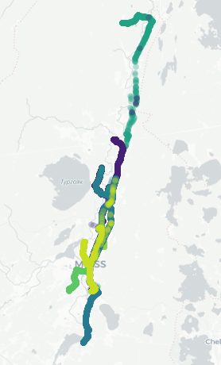

Ниже будет приведена визуализация некотрых рейсов.

### Маршрут 3

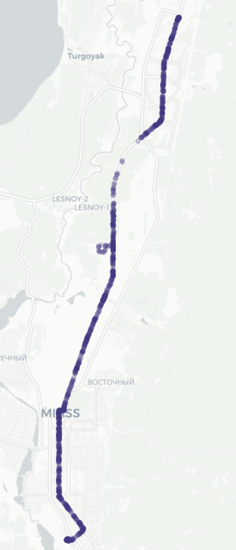

Это троллейбусный маршрут, согласно предоставленным данным. На карте что частично запись есть и на территории троллейбусного депо. Достаточно мало точек наблюдается в "лесистой местности". Вероятно мобильный сигнал и сигнал GPS/ГЛОНАС в этом районе ловит хуже, чем в городе или транспортное средство в этой части едет быстрее среднего. В будущем можно провести доп анализ.

```python
df_raise[df_raise["route"] == "3"][:1]
```

|  | average_speed | clid | direction | lat | lon | receive_time | route | time | uuid | vehicle_type | raises |
| --- | --- | --- | --- | --- | --- | --- | --- | --- | --- | --- | --- |
| 0 | 4.444 | c8g87gcr3 | 182.000 | 55.148 | 60.152 | 1701392963 | 3 | 1701392958 | 1463169 | trolleybus | 3_1463169_1 |

### Маршрут 4

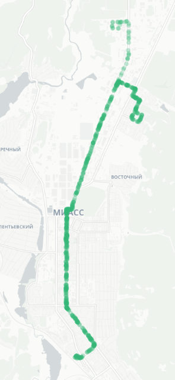

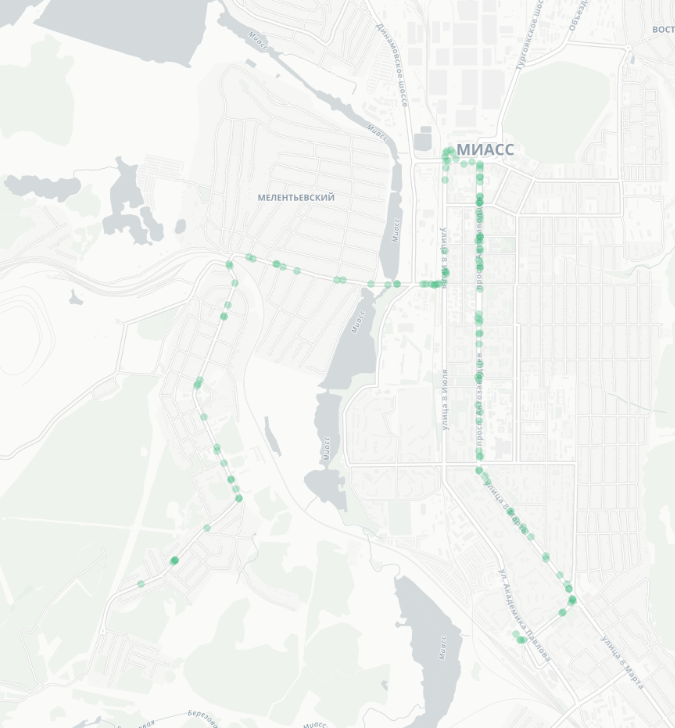

В данных возможно ошибка. Т.к. встречаются разные маршруты, хотя по данным свободных источников этот маршрут должен соответствовать второму рисунку данного раздеала. Это может быть связано с тем, что одно и тоже траспортное средство может следовать по нескольким маршрутам. При этом информация о маршруте в транспортном средстве может не переключаться.

Пример строки маршрута 4:

```python
df_raise[df_raise["route"] == "4"][:1]
```

|  | average_speed | clid | direction | lat | lon | receive_time | route | time | uuid | vehicle_type | raises |
| --- | --- | --- | --- | --- | --- | --- | --- | --- | --- | --- | --- |
| 13353 | 6.111 | c8g87gcr3 | 0.000 | 55.061 | 60.108 | 1701394401 | 4 | 1701394392 | 1504624 | trolleybus | 4_1504624_2 |

### Маршрут 291

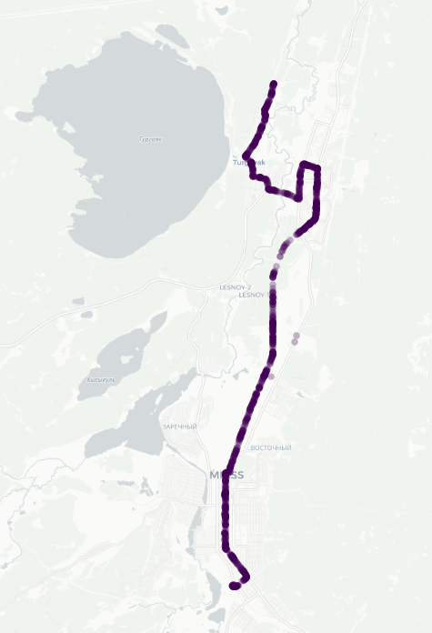

```python
df_raise[df_raise["route"] == "291"][:1]
```

|  | average_speed | clid | direction | lat | lon | receive_time | route | time | uuid | vehicle_type | raises |
| --- | --- | --- | --- | --- | --- | --- | --- | --- | --- | --- | --- |
| 36942 | 0.278 | c8g87gcr3 | 0.000 | 55.140 | 60.152 | 1701393233 | 291 | 1701393224 | 1504908 | trolleybus | 291_1504908_1 |

По предоставленным данным маршрут 291 это троллейбусный маршрут, однако, судя по карте это не так. Согласно свободным источникам это автобусный маршрут. Наблюдаются выскочившие точки из основного маршрута, что может быть связано с ошибками в определении местоположения транспортного средства.